# Exercises

## Section 3.2 exercises

1. In a single pipeline for each condition, find all flights that meet the condition:
   - Had an arrival delay of two or more hours
   - Flew to Houston (`IAH` or `HOU`)
   - Were operated by United, American, or Delta
   - Departed in summer (July, August, and September)
   - Arrived more than two hours late but didn’t leave late
   - Were delayed by at least an hour, but made up over 30 minutes in flight  
     A:

   ```r
   flights |> filter(dep_delay >= 120)
   ```

   ```
   ## # A tibble: 9,888 × 19
   ##     year month   day dep_time sched_dep_time dep_delay arr_time sched_arr_time
   ##    <int> <int> <int>    <int>          <int>     <dbl>    <int>          <int>
   ##  1  2013     1     1      848           1835       853     1001           1950
   ##  2  2013     1     1      957            733       144     1056            853
   ##  3  2013     1     1     1114            900       134     1447           1222
   ##  4  2013     1     1     1540           1338       122     2020           1825
   ##  5  2013     1     1     1815           1325       290     2120           1542
   ##  6  2013     1     1     1842           1422       260     1958           1535
   ##  7  2013     1     1     1856           1645       131     2212           2005
   ##  8  2013     1     1     1934           1725       129     2126           1855
   ##  9  2013     1     1     1938           1703       155     2109           1823
   ## 10  2013     1     1     1942           1705       157     2124           1830
   ## # ℹ 9,878 more rows
   ## # ℹ 11 more variables: arr_delay <dbl>, carrier <chr>, flight <int>,
   ## #   tailnum <chr>, origin <chr>, dest <chr>, air_time <dbl>, distance <dbl>,
   ## #   hour <dbl>, minute <dbl>, time_hour <dttm>
   ```

   ```r
   flights |> filter(dest %in% c("IAH", "HOU"))
   ```

   ```
   ## # A tibble: 9,313 × 19
   ##     year month   day dep_time sched_dep_time dep_delay arr_time sched_arr_time
   ##    <int> <int> <int>    <int>          <int>     <dbl>    <int>          <int>
   ##  1  2013     1     1      517            515         2      830            819
   ##  2  2013     1     1      533            529         4      850            830
   ##  3  2013     1     1      623            627        -4      933            932
   ##  4  2013     1     1      728            732        -4     1041           1038
   ##  5  2013     1     1      739            739         0     1104           1038
   ##  6  2013     1     1      908            908         0     1228           1219
   ##  7  2013     1     1     1028           1026         2     1350           1339
   ##  8  2013     1     1     1044           1045        -1     1352           1351
   ##  9  2013     1     1     1114            900       134     1447           1222
   ## 10  2013     1     1     1205           1200         5     1503           1505
   ## # ℹ 9,303 more rows
   ## # ℹ 11 more variables: arr_delay <dbl>, carrier <chr>, flight <int>,
   ## #   tailnum <chr>, origin <chr>, dest <chr>, air_time <dbl>, distance <dbl>,
   ## #   hour <dbl>, minute <dbl>, time_hour <dttm>
   ```

   ```r
   flights |> filter(carrier %in% c("UA", "AA", "DL"))
   ```

   ```
   ## # A tibble: 139,504 × 19
   ##     year month   day dep_time sched_dep_time dep_delay arr_time sched_arr_time
   ##    <int> <int> <int>    <int>          <int>     <dbl>    <int>          <int>
   ##  1  2013     1     1      517            515         2      830            819
   ##  2  2013     1     1      533            529         4      850            830
   ##  3  2013     1     1      542            540         2      923            850
   ##  4  2013     1     1      554            600        -6      812            837
   ##  5  2013     1     1      554            558        -4      740            728
   ##  6  2013     1     1      558            600        -2      753            745
   ##  7  2013     1     1      558            600        -2      924            917
   ##  8  2013     1     1      558            600        -2      923            937
   ##  9  2013     1     1      559            600        -1      941            910
   ## 10  2013     1     1      559            600        -1      854            902
   ## # ℹ 139,494 more rows
   ## # ℹ 11 more variables: arr_delay <dbl>, carrier <chr>, flight <int>,
   ## #   tailnum <chr>, origin <chr>, dest <chr>, air_time <dbl>, distance <dbl>,
   ## #   hour <dbl>, minute <dbl>, time_hour <dttm>
   ```

   ```r
   flights |> filter(month %in% c(7, 8, 9))
   ```

   ```
   ## # A tibble: 86,326 × 19
   ##     year month   day dep_time sched_dep_time dep_delay arr_time sched_arr_time
   ##    <int> <int> <int>    <int>          <int>     <dbl>    <int>          <int>
   ##  1  2013     7     1        1           2029       212      236           2359
   ##  2  2013     7     1        2           2359         3      344            344
   ##  3  2013     7     1       29           2245       104      151              1
   ##  4  2013     7     1       43           2130       193      322             14
   ##  5  2013     7     1       44           2150       174      300            100
   ##  6  2013     7     1       46           2051       235      304           2358
   ##  7  2013     7     1       48           2001       287      308           2305
   ##  8  2013     7     1       58           2155       183      335             43
   ##  9  2013     7     1      100           2146       194      327             30
   ## 10  2013     7     1      100           2245       135      337            135
   ## # ℹ 86,316 more rows
   ## # ℹ 11 more variables: arr_delay <dbl>, carrier <chr>, flight <int>,
   ## #   tailnum <chr>, origin <chr>, dest <chr>, air_time <dbl>, distance <dbl>,
   ## #   hour <dbl>, minute <dbl>, time_hour <dttm>
   ```

   ```r
   flights |> filter(dep_delay <= 0 & arr_delay > 120)
   ```

   ```
   ## # A tibble: 29 × 19
   ##     year month   day dep_time sched_dep_time dep_delay arr_time sched_arr_time
   ##    <int> <int> <int>    <int>          <int>     <dbl>    <int>          <int>
   ##  1  2013     1    27     1419           1420        -1     1754           1550
   ##  2  2013    10     7     1350           1350         0     1736           1526
   ##  3  2013    10     7     1357           1359        -2     1858           1654
   ##  4  2013    10    16      657            700        -3     1258           1056
   ##  5  2013    11     1      658            700        -2     1329           1015
   ##  6  2013     3    18     1844           1847        -3       39           2219
   ##  7  2013     4    17     1635           1640        -5     2049           1845
   ##  8  2013     4    18      558            600        -2     1149            850
   ##  9  2013     4    18      655            700        -5     1213            950
   ## 10  2013     5    22     1827           1830        -3     2217           2010
   ## # ℹ 19 more rows
   ## # ℹ 11 more variables: arr_delay <dbl>, carrier <chr>, flight <int>,
   ## #   tailnum <chr>, origin <chr>, dest <chr>, air_time <dbl>, distance <dbl>,
   ## #   hour <dbl>, minute <dbl>, time_hour <dttm>
   ```

   ```r
   flights |> filter(dep_delay >= 60 & dep_delay - arr_delay >= 30)
   ```

   ```
   ## # A tibble: 2,074 × 19
   ##     year month   day dep_time sched_dep_time dep_delay arr_time sched_arr_time
   ##    <int> <int> <int>    <int>          <int>     <dbl>    <int>          <int>
   ##  1  2013     1     1     1716           1545        91     2140           2039
   ##  2  2013     1     1     2205           1720       285       46           2040
   ##  3  2013     1     1     2326           2130       116      131             18
   ##  4  2013     1     3     1503           1221       162     1803           1555
   ##  5  2013     1     3     1821           1530       171     2131           1910
   ##  6  2013     1     3     1839           1700        99     2056           1950
   ##  7  2013     1     3     1850           1745        65     2148           2120
   ##  8  2013     1     3     1923           1815        68     2036           1958
   ##  9  2013     1     3     1941           1759       102     2246           2139
   ## 10  2013     1     3     1950           1845        65     2228           2227
   ## # ℹ 2,064 more rows
   ## # ℹ 11 more variables: arr_delay <dbl>, carrier <chr>, flight <int>,
   ## #   tailnum <chr>, origin <chr>, dest <chr>, air_time <dbl>, distance <dbl>,
   ## #   hour <dbl>, minute <dbl>, time_hour <dttm>
   ```

2. Sort `flights` to find the flights with the longest departure delays. Find the flights that left earliest in the morning.  
   A:

   ```r
   flights |> arrange(desc(dep_delay))
   ```

   ```
   ## # A tibble: 336,776 × 19
   ##     year month   day dep_time sched_dep_time dep_delay arr_time sched_arr_time
   ##    <int> <int> <int>    <int>          <int>     <dbl>    <int>          <int>
   ##  1  2013     1     9      641            900      1301     1242           1530
   ##  2  2013     6    15     1432           1935      1137     1607           2120
   ##  3  2013     1    10     1121           1635      1126     1239           1810
   ##  4  2013     9    20     1139           1845      1014     1457           2210
   ##  5  2013     7    22      845           1600      1005     1044           1815
   ##  6  2013     4    10     1100           1900       960     1342           2211
   ##  7  2013     3    17     2321            810       911      135           1020
   ##  8  2013     6    27      959           1900       899     1236           2226
   ##  9  2013     7    22     2257            759       898      121           1026
   ## 10  2013    12     5      756           1700       896     1058           2020
   ## # ℹ 336,766 more rows
   ## # ℹ 11 more variables: arr_delay <dbl>, carrier <chr>, flight <int>,
   ## #   tailnum <chr>, origin <chr>, dest <chr>, air_time <dbl>, distance <dbl>,
   ## #   hour <dbl>, minute <dbl>, time_hour <dttm>
   ```

   ```r
   flights |> arrange(dep_time)
   ```

   ```
   ## # A tibble: 336,776 × 19
   ##     year month   day dep_time sched_dep_time dep_delay arr_time sched_arr_time
   ##    <int> <int> <int>    <int>          <int>     <dbl>    <int>          <int>
   ##  1  2013     1    13        1           2249        72      108           2357
   ##  2  2013     1    31        1           2100       181      124           2225
   ##  3  2013    11    13        1           2359         2      442            440
   ##  4  2013    12    16        1           2359         2      447            437
   ##  5  2013    12    20        1           2359         2      430            440
   ##  6  2013    12    26        1           2359         2      437            440
   ##  7  2013    12    30        1           2359         2      441            437
   ##  8  2013     2    11        1           2100       181      111           2225
   ##  9  2013     2    24        1           2245        76      121           2354
   ## 10  2013     3     8        1           2355         6      431            440
   ## # ℹ 336,766 more rows
   ## # ℹ 11 more variables: arr_delay <dbl>, carrier <chr>, flight <int>,
   ## #   tailnum <chr>, origin <chr>, dest <chr>, air_time <dbl>, distance <dbl>,
   ## #   hour <dbl>, minute <dbl>, time_hour <dttm>
   ```

3. Sort `flights` to find the fastest flights. (Hint: Try including a math calculation inside of your function.)  
   A:

   ```r
   flights |> arrange(desc(distance / air_time))
   ```

   ```
   ## # A tibble: 336,776 × 19
   ##     year month   day dep_time sched_dep_time dep_delay arr_time sched_arr_time
   ##    <int> <int> <int>    <int>          <int>     <dbl>    <int>          <int>
   ##  1  2013     5    25     1709           1700         9     1923           1937
   ##  2  2013     7     2     1558           1513        45     1745           1719
   ##  3  2013     5    13     2040           2025        15     2225           2226
   ##  4  2013     3    23     1914           1910         4     2045           2043
   ##  5  2013     1    12     1559           1600        -1     1849           1917
   ##  6  2013    11    17      650            655        -5     1059           1150
   ##  7  2013     2    21     2355           2358        -3      412            438
   ##  8  2013    11    17      759            800        -1     1212           1255
   ##  9  2013    11    16     2003           1925        38       17             36
   ## 10  2013    11    16     2349           2359       -10      402            440
   ## # ℹ 336,766 more rows
   ## # ℹ 11 more variables: arr_delay <dbl>, carrier <chr>, flight <int>,
   ## #   tailnum <chr>, origin <chr>, dest <chr>, air_time <dbl>, distance <dbl>,
   ## #   hour <dbl>, minute <dbl>, time_hour <dttm>
   ```

4. Was there a flight on every day of 2013?  
   A: Yes.

   ```r
   flights |> distinct(month, day)
   ```

   ```
   ## # A tibble: 365 × 2
   ##    month   day
   ##    <int> <int>
   ##  1     1     1
   ##  2     1     2
   ##  3     1     3
   ##  4     1     4
   ##  5     1     5
   ##  6     1     6
   ##  7     1     7
   ##  8     1     8
   ##  9     1     9
   ## 10     1    10
   ## # ℹ 355 more rows
   ```

5. Which flights traveled the farthest distance? Which traveled the least distance?

   ```r
   flights |> arrange(desc(distance))
   ```

   ```
   ## # A tibble: 336,776 × 19
   ##     year month   day dep_time sched_dep_time dep_delay arr_time sched_arr_time
   ##    <int> <int> <int>    <int>          <int>     <dbl>    <int>          <int>
   ##  1  2013     1     1      857            900        -3     1516           1530
   ##  2  2013     1     2      909            900         9     1525           1530
   ##  3  2013     1     3      914            900        14     1504           1530
   ##  4  2013     1     4      900            900         0     1516           1530
   ##  5  2013     1     5      858            900        -2     1519           1530
   ##  6  2013     1     6     1019            900        79     1558           1530
   ##  7  2013     1     7     1042            900       102     1620           1530
   ##  8  2013     1     8      901            900         1     1504           1530
   ##  9  2013     1     9      641            900      1301     1242           1530
   ## 10  2013     1    10      859            900        -1     1449           1530
   ## # ℹ 336,766 more rows
   ## # ℹ 11 more variables: arr_delay <dbl>, carrier <chr>, flight <int>,
   ## #   tailnum <chr>, origin <chr>, dest <chr>, air_time <dbl>, distance <dbl>,
   ## #   hour <dbl>, minute <dbl>, time_hour <dttm>
   ```

   ```r
   flights |> arrange(distance)
   ```

   ```
   ## # A tibble: 336,776 × 19
   ##     year month   day dep_time sched_dep_time dep_delay arr_time sched_arr_time
   ##    <int> <int> <int>    <int>          <int>     <dbl>    <int>          <int>
   ##  1  2013     7    27       NA            106        NA       NA            245
   ##  2  2013     1     3     2127           2129        -2     2222           2224
   ##  3  2013     1     4     1240           1200        40     1333           1306
   ##  4  2013     1     4     1829           1615       134     1937           1721
   ##  5  2013     1     4     2128           2129        -1     2218           2224
   ##  6  2013     1     5     1155           1200        -5     1241           1306
   ##  7  2013     1     6     2125           2129        -4     2224           2224
   ##  8  2013     1     7     2124           2129        -5     2212           2224
   ##  9  2013     1     8     2127           2130        -3     2304           2225
   ## 10  2013     1     9     2126           2129        -3     2217           2224
   ## # ℹ 336,766 more rows
   ## # ℹ 11 more variables: arr_delay <dbl>, carrier <chr>, flight <int>,
   ## #   tailnum <chr>, origin <chr>, dest <chr>, air_time <dbl>, distance <dbl>,
   ## #   hour <dbl>, minute <dbl>, time_hour <dttm>
   ```

6. Does it matter what order you used `filter()` and `arrange()` if you’re using both? Why/why not? Think about the results and how much work the functions would have to do.  
   A: The resulting data frame should be the same, but if we apply `arrange()` first, it’ll need to sort through rows that are only to be discarded later by `filter()`. Applying `filter()` first would be more efficient.

# Section 3.3 exercises

1. Compare `dep_time`, `sched_dep_time`, and `dep_delay`. How would you expect those three numbers to be related?  
   A: `dep_delay == (dep_time %% 100 - sched_dep_time %% 100) + (dep_time %/% 100 - sched_dep_time %/% 100) * 60`
2. Brainstorm as many ways as possible to select `dep_time`, `dep_delay`, `arr_time`, and `arr_delay` from `flights`.  
   A:

   ```r
   flights |> select(starts_with(c("dep", "arr")))
   ```

   ```
   ## # A tibble: 336,776 × 4
   ##    dep_time dep_delay arr_time arr_delay
   ##       <int>     <dbl>    <int>     <dbl>
   ##  1      517         2      830        11
   ##  2      533         4      850        20
   ##  3      542         2      923        33
   ##  4      544        -1     1004       -18
   ##  5      554        -6      812       -25
   ##  6      554        -4      740        12
   ##  7      555        -5      913        19
   ##  8      557        -3      709       -14
   ##  9      557        -3      838        -8
   ## 10      558        -2      753         8
   ## # ℹ 336,766 more rows
   ```

3. What happens if you specify the name of the same variable multiple times in a `select()` call?  
   A: multiple same variables register only once in the output of `select()`.

   ```r
   flights |> select("tailnum", "tailnum")
   ```

   ```
   ## # A tibble: 336,776 × 1
   ##    tailnum
   ##    <chr>
   ##  1 N14228
   ##  2 N24211
   ##  3 N619AA
   ##  4 N804JB
   ##  5 N668DN
   ##  6 N39463
   ##  7 N516JB
   ##  8 N829AS
   ##  9 N593JB
   ## 10 N3ALAA
   ## # ℹ 336,766 more rows
   ```

4. What does the `any_of()` function do? Why might it be helpful in conjunction with this vector?

   ```r
   variables <- c("year", "month", "day", "dep_delay", "arr_delay")
   ```

   A: `any_of()` doesn’t check for missing values, i.e., it doesn’t throw an error when a variable specified isn’t present in the data frame.
5. Does the result of running the following code surprise you? How do the select helpers deal with upper and lower case by default? How can you change that default?

   ```r
   flights |> select(contains("TIME"))
   ```

   ```
   ## # A tibble: 336,776 × 6
   ##    dep_time sched_dep_time arr_time sched_arr_time air_time time_hour
   ##       <int>          <int>    <int>          <int>    <dbl> <dttm>
   ##  1      517            515      830            819      227 2013-01-01 05:00:00
   ##  2      533            529      850            830      227 2013-01-01 05:00:00
   ##  3      542            540      923            850      160 2013-01-01 05:00:00
   ##  4      544            545     1004           1022      183 2013-01-01 05:00:00
   ##  5      554            600      812            837      116 2013-01-01 06:00:00
   ##  6      554            558      740            728      150 2013-01-01 05:00:00
   ##  7      555            600      913            854      158 2013-01-01 06:00:00
   ##  8      557            600      709            723       53 2013-01-01 06:00:00
   ##  9      557            600      838            846      140 2013-01-01 06:00:00
   ## 10      558            600      753            745      138 2013-01-01 06:00:00
   ## # ℹ 336,766 more rows
   ```

   A: quite surprising that `contains()` defaults to ignoring upper and lower cases. setting the argument `ignore.case` to `FALSE` helps `contains()` distinguish cases.

   ```r
   flights |> select(contains("TIME", ignore.case = FALSE))
   ```

   ```
   ## # A tibble: 336,776 × 0
   ```

6. Rename `air_time` to `air_time_min` to indicate units of measurement and move it to the beginning of the data frame.  
   A:

   ```r
   flights |> relocate(air_time_min = air_time)
   ```

   ```
   ## # A tibble: 336,776 × 19
   ##    air_time_min  year month   day dep_time sched_dep_time dep_delay arr_time
   ##           <dbl> <int> <int> <int>    <int>          <int>     <dbl>    <int>
   ##  1          227  2013     1     1      517            515         2      830
   ##  2          227  2013     1     1      533            529         4      850
   ##  3          160  2013     1     1      542            540         2      923
   ##  4          183  2013     1     1      544            545        -1     1004
   ##  5          116  2013     1     1      554            600        -6      812
   ##  6          150  2013     1     1      554            558        -4      740
   ##  7          158  2013     1     1      555            600        -5      913
   ##  8           53  2013     1     1      557            600        -3      709
   ##  9          140  2013     1     1      557            600        -3      838
   ## 10          138  2013     1     1      558            600        -2      753
   ## # ℹ 336,766 more rows
   ## # ℹ 11 more variables: sched_arr_time <int>, arr_delay <dbl>, carrier <chr>,
   ## #   flight <int>, tailnum <chr>, origin <chr>, dest <chr>, distance <dbl>,
   ## #   hour <dbl>, minute <dbl>, time_hour <dttm>
   ```

7. Why doesn’t the following work, and what does the error mean?

   ```r
   flights |>
     select(tailnum) |>
     arrange(arr_delay)
   ```

   ```
   ## Error in `arrange()`:
   ## ℹ In argument: `..1 = arr_delay`.
   ## Caused by error:
   ## ! object 'arr_delay' not found
   ```

   A: variable `arr_delay` doesn’t exist anymore after selecting only `tailnum`.

## Section 3.5 exercises

1. Which carrier has the worst average delays? Challenge: can you disentangle the effects of bad airports vs. bad carriers? Why/why not? (Hint: think about `flights |> group_by(carrier, dest) |> summarize(n())`)  
   A: We might not be able to differentiate whether delays were caused by airports or carriers, because carrier and airports are not independent variables (certain carriers may deal with flights to certain destinations more than others.)

   ```r
   flights |>
     summarize(
       avg_delay = mean(dep_delay, na.rm = TRUE),
       .by = carrier
     ) |>
     arrange(desc(avg_delay))
   ```

   ```
   ## # A tibble: 16 × 2
   ##    carrier avg_delay
   ##    <chr>       <dbl>
   ##  1 F9          20.2
   ##  2 EV          20.0
   ##  3 YV          19.0
   ##  4 FL          18.7
   ##  5 WN          17.7
   ##  6 9E          16.7
   ##  7 B6          13.0
   ##  8 VX          12.9
   ##  9 OO          12.6
   ## 10 UA          12.1
   ## 11 MQ          10.6
   ## 12 DL           9.26
   ## 13 AA           8.59
   ## 14 AS           5.80
   ## 15 HA           4.90
   ## 16 US           3.78
   ```

2. Find the flights that are most delayed upon departure to each destination.  
   A:

   ```r
   flights |>
     group_by(dest) |>
     slice_max(dep_delay, n = 1) |>
     relocate(dest)
   ```

   ```
   ## # A tibble: 105 × 19
   ## # Groups:   dest [105]
   ##    dest   year month   day dep_time sched_dep_time dep_delay arr_time
   ##    <chr> <int> <int> <int>    <int>          <int>     <dbl>    <int>
   ##  1 ABQ    2013    12    14     2223           2001       142      133
   ##  2 ACK    2013     7    23     1139            800       219     1250
   ##  3 ALB    2013     1    25      123           2000       323      229
   ##  4 ANC    2013     8    17     1740           1625        75     2042
   ##  5 ATL    2013     7    22     2257            759       898      121
   ##  6 AUS    2013     7    10     2056           1505       351     2347
   ##  7 AVL    2013     6    14     1158            816       222     1335
   ##  8 BDL    2013     2    21     1728           1316       252     1839
   ##  9 BGR    2013    12     1     1504           1056       248     1628
   ## 10 BHM    2013     4    10       25           1900       325      136
   ## # ℹ 95 more rows
   ## # ℹ 11 more variables: sched_arr_time <int>, arr_delay <dbl>, carrier <chr>,
   ## #   flight <int>, tailnum <chr>, origin <chr>, air_time <dbl>, distance <dbl>,
   ## #   hour <dbl>, minute <dbl>, time_hour <dttm>
   ```

3. How do delays vary over the course of the day? Illustrate your answer with a plot.  
   A:

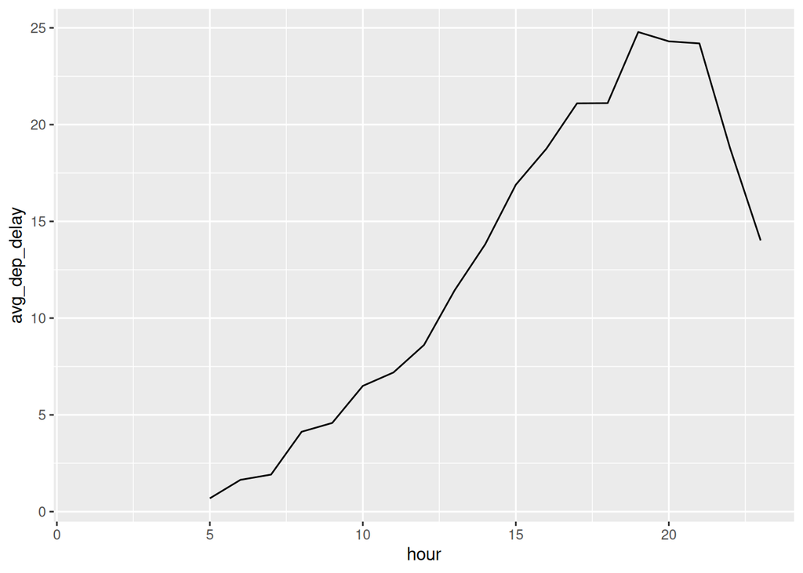

   ```r
   avg_delays_by_hour <- flights |>
     select(dep_delay, arr_delay, hour) |>
     summarize(
       avg_dep_delay = mean(dep_delay, na.rm = TRUE),
       avg_arr_delay = mean(arr_delay, na.rm = TRUE),
       .by = hour
     )
   ggplot(avg_delays_by_hour, aes(x = hour, y = avg_dep_delay)) +
     geom_line()
   ```

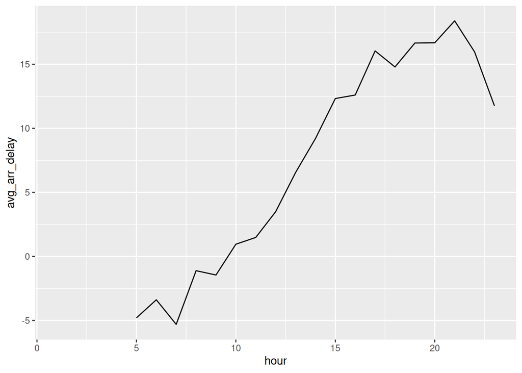

   ```r
   ggplot(avg_delays_by_hour, aes(x = hour, y = avg_arr_delay)) +
     geom_line()
   ```

4. What happens if you supply a negative `n` to `slice_min()` and friends?  
   A: a negative value of `n` will be subtracted from the group size.

   ```r
   flights |>
     group_by(month) |>
     slice_min(dep_delay, n = 1)
   ```

   ```
   ## # A tibble: 14 × 19
   ## # Groups:   month [12]
   ##     year month   day dep_time sched_dep_time dep_delay arr_time sched_arr_time
   ##    <int> <int> <int>    <int>          <int>     <dbl>    <int>          <int>
   ##  1  2013     1    11     1900           1930       -30     2233           2243
   ##  2  2013     2     3     2022           2055       -33     2240           2338
   ##  3  2013     3    30     2030           2055       -25     2213           2250
   ##  4  2013     4     5      540            601       -21      703            709
   ##  5  2013     4     8     2039           2100       -21     2308           2338
   ##  6  2013     5     5      934            958       -24     1225           1309
   ##  7  2013     5    14      914            938       -24     1143           1204
   ##  8  2013     6     5     1908           1929       -21     2057           2109
   ##  9  2013     7    29     1933           1955       -22     2113           2145
   ## 10  2013     8     9      729            755       -26     1002            955
   ## 11  2013     9    18     1631           1655       -24     1812           1845
   ## 12  2013    10    23     1907           1932       -25     2143           2143
   ## 13  2013    11    10     1408           1440       -32     1549           1559
   ## 14  2013    12     7     2040           2123       -43       40           2352
   ## # ℹ 11 more variables: arr_delay <dbl>, carrier <chr>, flight <int>,
   ## #   tailnum <chr>, origin <chr>, dest <chr>, air_time <dbl>, distance <dbl>,
   ## #   hour <dbl>, minute <dbl>, time_hour <dttm>
   ```

   ```r
   flights |>
     group_by(month) |>
     slice_min(dep_delay, n = -1)
   ```

5. Explain what `count()` does in terms of the dplyr verbs you just learned. What does the `sort` argument to `count()` do?  
   A: `count()` can be implemented by `group_by()` and `n()`. The `sort` argument if set to `TRUE`, sorts the rows descendingly by count.

   ```r
   flights |>
     count(month)
   ```

   ```
   ## # A tibble: 12 × 2
   ##    month     n
   ##    <int> <int>
   ##  1     1 27004
   ##  2     2 24951
   ##  3     3 28834
   ##  4     4 28330
   ##  5     5 28796
   ##  6     6 28243
   ##  7     7 29425
   ##  8     8 29327
   ##  9     9 27574
   ## 10    10 28889
   ## 11    11 27268
   ## 12    12 28135
   ```

   ```r
   flights |>
     group_by(month) |>
     summarize(n = n())
   ```

   ```
   ## # A tibble: 12 × 2
   ##    month     n
   ##    <int> <int>
   ##  1     1 27004
   ##  2     2 24951
   ##  3     3 28834
   ##  4     4 28330
   ##  5     5 28796
   ##  6     6 28243
   ##  7     7 29425
   ##  8     8 29327
   ##  9     9 27574
   ## 10    10 28889
   ## 11    11 27268
   ## 12    12 28135
   ```

6. Suppose we have the following tiny data frame:

   ```r
   df <- tibble(
     x = 1:5,
     y = c("a", "b", "a", "a", "b"),
     z = c("K", "K", "L", "L", "K")
   )
   ```

   1. Write down what you think the output will look like, then check if you were correct, and describe what `group_by()` does.

      ```r
      df |>
        group_by(y)
      ```

      ```
      ## # A tibble: 5 × 3
      ## # Groups:   y [2]
      ##       x y     z
      ##   <int> <chr> <chr>
      ## 1     1 a     K
      ## 2     2 b     K
      ## 3     3 a     L
      ## 4     4 a     L
      ## 5     5 b     K
      ```

   2. Write down what you think the output will look like, then check if you were correct, and describe what `arrange()` does. Also, comment on how it’s different from the `group_by()` in part (a).

      ```r
      df |>
        arrange(y)
      ```

      ```
      ## # A tibble: 5 × 3
      ##       x y     z
      ##   <int> <chr> <chr>
      ## 1     1 a     K
      ## 2     3 a     L
      ## 3     4 a     L
      ## 4     2 b     K
      ## 5     5 b     K
      ```

   3. Write down what you think the output will look like, then check if you were correct, and describe what the pipeline does.

      ```r
      df |>
        group_by(y) |>
        summarize(mean_x = mean(x))
      ```

      ```
      ## # A tibble: 2 × 2
      ##   y     mean_x
      ##   <chr>  <dbl>
      ## 1 a       2.67
      ## 2 b       3.5
      ```

   4. Write down what you think the output will look like, then check if you were correct, and describe what the pipeline does. Then, comment on what the message says.

      ```r
      df |>
        group_by(y, z) |>
        summarize(mean_x = mean(x))
      ```

      ```
      ## # A tibble: 3 × 3
      ## # Groups:   y [2]
      ##   y     z     mean_x
      ##   <chr> <chr>  <dbl>
      ## 1 a     K        1
      ## 2 a     L        3.5
      ## 3 b     K        3.5
      ```

   5. Write down what you think the output will look like, then check if you were correct, and describe what the pipeline does. How is the output different from the one in part (d)?

      ```r
      df |>
        group_by(y, z) |>
        summarize(mean_x = mean(x), .groups = "drop")
      ```

      ```
      ## # A tibble: 3 × 3
      ##   y     z     mean_x
      ##   <chr> <chr>  <dbl>
      ## 1 a     K        1
      ## 2 a     L        3.5
      ## 3 b     K        3.5
      ```

   6. Write down what you think the outputs will look like, then check if you were correct, and describe what each pipeline does. How are the outputs of the two pipelines different?

      ```r
      df |>
        group_by(y, z) |>
        summarize(mean_x = mean(x))
      ```

      ```
      ## # A tibble: 3 × 3
      ## # Groups:   y [2]
      ##   y     z     mean_x
      ##   <chr> <chr>  <dbl>
      ## 1 a     K        1
      ## 2 a     L        3.5
      ## 3 b     K        3.5
      ```

      ```r
      df |>
        group_by(y, z) |>
        mutate(mean_x = mean(x))
      ```

      ```
      ## # A tibble: 5 × 4
      ## # Groups:   y, z [3]
      ##       x y     z     mean_x
      ##   <int> <chr> <chr>  <dbl>
      ## 1     1 a     K        1
      ## 2     2 b     K        3.5
      ## 3     3 a     L        3.5
      ## 4     4 a     L        3.5
      ## 5     5 b     K        3.5
      ```